# Machine Learning: Classification of Barbell Lift Data

Gareth Houk

Tuesday, January 20, 2015

Load libraries:

```r
require(caret)
require(lattice)
```

## Executive Summary

We create a machine-learning algorithm for predicting which of five categories of exercise is being performed based on a large dataset of sensor data. We split the data set into training and validation sets and attempt three different modeling techniques. The best out-of-sample error rate is achieved with the Random Forest algorithm, which we adopt and apply successfully to a 20-sample “test” data set.

## Introduction

For graders, I have measured the number of words in this document to be 1261 excluding code output. Thanks for grading!

Our purpose is to predict which of 5 different exercises subjects are performing in a 20 element test set where the exercise label is hidden. Modeling may proceed from a large dataset consisting of 19622 samples of 160 variables including the revealed exercise labels (variable classe with valid levels A, B, C, D, E).

## Analytic Outline

Creating a prediction model consists of six steps. We note as follows an outline of how we will proceed.

- Question. Our goal is to create a model which accurately predicts the exercise in the test sample. We want to get a perfect score on the assignment, so naturally we will always put priority on accuracy over such considerations as interpretability, speed, simplicity, and scalability.
- Input Data. Our input data is as described above.
- Features. We must determine which features of the data are useful in achieving an optimal answer to our data modeling question. In the “Exploratory Data Analysis” section below, we address pre-processing of the data with this goal in mind.
- Algorithm. We have a large number of algorithms available for modeling, however, few are appropriate to the outcome variable, a factor variable with five discrete levels. The only models we consider are therefore classification trees, linear discriminant analysis and random forests. Other algorithms such as regressions and generalized linear models are not natural fits to categorical independent variables. A boosted tree model proved prohibitively CPU-intensive.
- Parameters. Once we have determined the likely best algorithm (i.e. the most accurate), we may tune its execution to arrive at the best possible results. In our case we will briefly explore the use of PCA pre-processing.
- Evaluation. The evaluation will consists of two parts: testing on a saved-out portion (“validation”) of the training set and then the final test of submiting the algorithm to evaluation through the test set.

## Exploratory Data Analysis

Since our main goal is success on the testing set, we will start by examining that data set.

### Missing variables

We note that there are 100 variables in the test set for which every entry is NA. There are NO variables in the training set for which every entry is NA, so valid data does exist for many of these features, however, as noted, they cannot help us to maximize accuracy in the test set (although obviously they may be useful in maximizing in-sample accuracy). Since we cannot possibly use these variables for test sample prediction, we immediately eliminate these variables in the training and test sets.

In addition, the first seven columns (X, user_name, raw_timestamp_part_1, raw_timestamp_part_2, cvtd_timestamp, new_window, num_window) are obviously not kinematic features, and so can be dropped. It is possible that user_name could be of use in prediction, but training the algorithm on individual subjects does not seem very sporting or generally applicable.

```r
names(trdata)
```

```
##  [1] "roll_belt"            "pitch_belt"           "yaw_belt"
##  [4] "total_accel_belt"     "gyros_belt_x"         "gyros_belt_y"
##  [7] "gyros_belt_z"         "accel_belt_x"         "accel_belt_y"
## [10] "accel_belt_z"         "magnet_belt_x"        "magnet_belt_y"
## [13] "magnet_belt_z"        "roll_arm"             "pitch_arm"
## [16] "yaw_arm"              "total_accel_arm"      "gyros_arm_x"
## [19] "gyros_arm_y"          "gyros_arm_z"          "accel_arm_x"
## [22] "accel_arm_y"          "accel_arm_z"          "magnet_arm_x"
## [25] "magnet_arm_y"         "magnet_arm_z"         "roll_dumbbell"
## [28] "pitch_dumbbell"       "yaw_dumbbell"         "total_accel_dumbbell"
## [31] "gyros_dumbbell_x"     "gyros_dumbbell_y"     "gyros_dumbbell_z"
## [34] "accel_dumbbell_x"     "accel_dumbbell_y"     "accel_dumbbell_z"
## [37] "magnet_dumbbell_x"    "magnet_dumbbell_y"    "magnet_dumbbell_z"
## [40] "roll_forearm"         "pitch_forearm"        "yaw_forearm"
## [43] "total_accel_forearm"  "gyros_forearm_x"      "gyros_forearm_y"
## [46] "gyros_forearm_z"      "accel_forearm_x"      "accel_forearm_y"
## [49] "accel_forearm_z"      "magnet_forearm_x"     "magnet_forearm_y"
## [52] "magnet_forearm_z"     "classe"
```

There were a LOT of missing variables in the original training set also, but all of the missing variables were the same as the ones missing in the test set. We can use the complete.cases function to show that 100% of the training set has entries for every variable.

### Low variance and Collinearity Check

We find that 0 variables in the training set have near-zero variance.

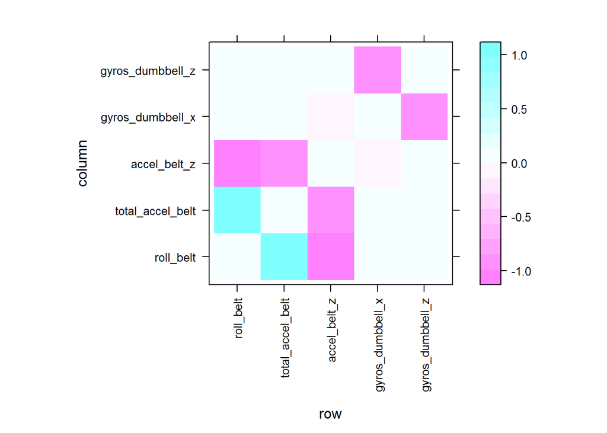

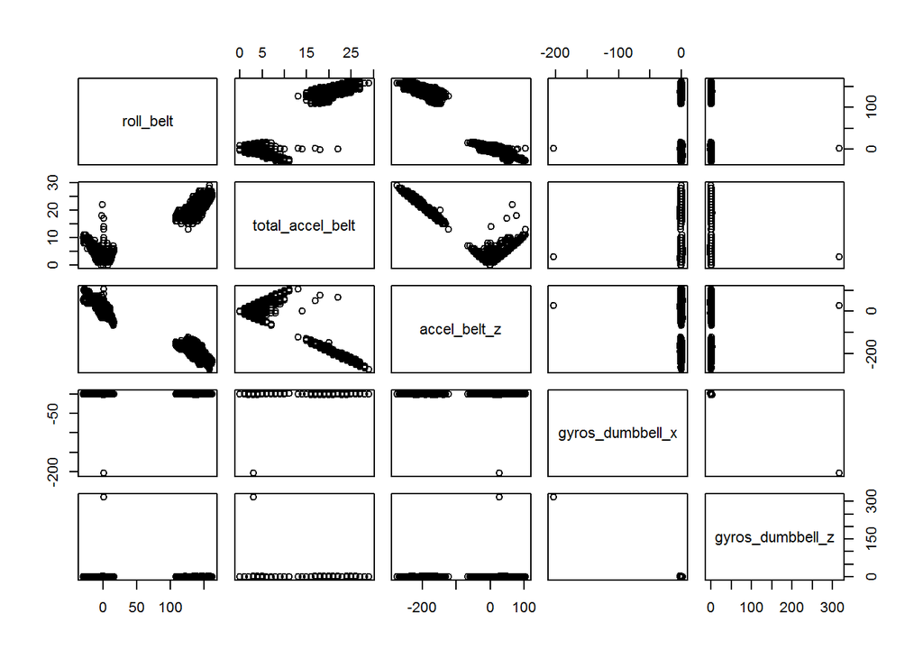

### Initial Models and Cross-Validation

We split the “training” CSV data set into a simple 70%/30% split between training and validation samples. We use the word “validation” to avoid the use of the word “test” sample, which has unfortunately been chosen for us with the 20 “quiz” samples for submission. But to be clear, the “training” sample will be used for model creation and the “validation” sample will be used for cross-validation.

```r
inTrain<-createDataPartition(y=trdata$classe,p=0.7,list=FALSE)
training <- trdata[inTrain,]
validation <- trdata[-inTrain,]
```

We attempt three initial models using all 52 features in the training set. Those models are a Classification and Regression Tree (“CART”; method=“rpart”), a Linear Discriminant Analysis model (“LDA”; method=“lda”), and a Random Forest model (“RF”; method=“rf”). In the RF model, we have chosen to use cross validation in the training control option. Cross validation in the “validation” sample follows model formation below. (The RF method training is long, so we have inserted code to measure its execution time for comparison below.)

```r
# Models
model_rpart <- train(classe ~. ,data=training,method="rpart")
model_lda   <- train(classe ~. ,data=training,method="lda")
set.seed(450921)
start.time <- Sys.time()
model_rf    <- train(classe~.,data=training,method="rf",trControl=trainControl(method = "cv", number = 4))
end.time <- Sys.time()
time.taken <- end.time - start.time
time.taken
```

```
## Time difference of 15.57096 mins
```

```r
time.takenRF<-time.taken
# Predictions in validation sample
pred_rpart  <- predict(model_rpart, validation)
pred_lda    <- predict(model_lda, validation)
pred_rf     <- predict(model_rf, validation)
```

Below we perform the cross-validations in the validation data set.

```r
# Cross validation
cm_rpart<-confusionMatrix(pred_rpart, validation$classe); print(cm_rpart)
```

```
## Confusion Matrix and Statistics
##
##           Reference
## Prediction    A    B    C    D    E
##          A 1523  467  489  415  181
##          B   32  392   31  191  155
##          C  116  280  506  358  264
##          D    0    0    0    0    0
##          E    3    0    0    0  482
##
## Overall Statistics
##
##                Accuracy : 0.4933
##                  95% CI : (0.4804, 0.5061)
##     No Information Rate : 0.2845
##     P-Value [Acc > NIR] : < 2.2e-16
##
##                   Kappa : 0.3374
##  Mcnemar's Test P-Value : NA
##
## Statistics by Class:
##
##                      Class: A Class: B Class: C Class: D Class: E
## Sensitivity            0.9098  0.34416  0.49318   0.0000  0.44547
## Specificity            0.6314  0.91382  0.79049   1.0000  0.99938
## Pos Pred Value         0.4953  0.48939  0.33202      NaN  0.99381
## Neg Pred Value         0.9463  0.85307  0.88076   0.8362  0.88889
## Prevalence             0.2845  0.19354  0.17434   0.1638  0.18386
## Detection Rate         0.2588  0.06661  0.08598   0.0000  0.08190
## Detection Prevalence   0.5225  0.13611  0.25896   0.0000  0.08241
## Balanced Accuracy      0.7706  0.62899  0.64183   0.5000  0.72242
```

```r
cm_lda  <-confusionMatrix(pred_lda  , validation$classe); print(cm_lda)
```

```
## Confusion Matrix and Statistics
##
##           Reference
## Prediction    A    B    C    D    E
##          A 1372  169   99   44   47
##          B   37  733   96   29  188
##          C  116  152  667  114  101
##          D  142   37  134  735   98
##          E    7   48   30   42  648
##
## Overall Statistics
##
##                Accuracy : 0.706
##                  95% CI : (0.6942, 0.7177)
##     No Information Rate : 0.2845
##     P-Value [Acc > NIR] : < 2.2e-16
##
##                   Kappa : 0.6281
##  Mcnemar's Test P-Value : < 2.2e-16
##
## Statistics by Class:
##
##                      Class: A Class: B Class: C Class: D Class: E
## Sensitivity            0.8196   0.6435   0.6501   0.7624   0.5989
## Specificity            0.9147   0.9263   0.9006   0.9165   0.9736
## Pos Pred Value         0.7926   0.6768   0.5800   0.6414   0.8361
## Neg Pred Value         0.9273   0.9155   0.9242   0.9517   0.9151
## Prevalence             0.2845   0.1935   0.1743   0.1638   0.1839
## Detection Rate         0.2331   0.1246   0.1133   0.1249   0.1101
## Detection Prevalence   0.2941   0.1840   0.1954   0.1947   0.1317
## Balanced Accuracy      0.8672   0.7849   0.7753   0.8395   0.7862
```

```r
cm_rf   <-confusionMatrix(pred_rf   , validation$classe); print(cm_rf)
```

```
## Confusion Matrix and Statistics
##
##           Reference
## Prediction    A    B    C    D    E
##          A 1673   11    0    0    0
##          B    0 1124    4    0    0
##          C    0    4 1022   12    0
##          D    0    0    0  952    1
##          E    1    0    0    0 1081
##
## Overall Statistics
##
##                Accuracy : 0.9944
##                  95% CI : (0.9921, 0.9961)
##     No Information Rate : 0.2845
##     P-Value [Acc > NIR] : < 2.2e-16
##
##                   Kappa : 0.9929
##  Mcnemar's Test P-Value : NA
##
## Statistics by Class:
##
##                      Class: A Class: B Class: C Class: D Class: E
## Sensitivity            0.9994   0.9868   0.9961   0.9876   0.9991
## Specificity            0.9974   0.9992   0.9967   0.9998   0.9998
## Pos Pred Value         0.9935   0.9965   0.9846   0.9990   0.9991
## Neg Pred Value         0.9998   0.9968   0.9992   0.9976   0.9998
## Prevalence             0.2845   0.1935   0.1743   0.1638   0.1839
## Detection Rate         0.2843   0.1910   0.1737   0.1618   0.1837
## Detection Prevalence   0.2862   0.1917   0.1764   0.1619   0.1839
## Balanced Accuracy      0.9984   0.9930   0.9964   0.9937   0.9994
```

We find that the RF model yields the highest Accuracy at 0.994, considerably higher than the values of 0.493 and 0.706 found in the CART and LDA methods. For this reason, we select the RF method for our model. One might argue that using three different algorithms and comparing their results on the validation set is an example of tuning the algorithm to the testing set. A truly proper comparison would be to split the original testing set into *three* samples, training and validation1 and validation2; model training would occur in the training set, model comparison and selection would occur in the validation1 set, and out-of-sample error would occur in the validation2 data set. While this is technically correct, the enormous difference in accuracy between the algorithms makes is clear that we are not introducing bias using the method we have chosen; we are merely picking a clearly superior algorithm.

### Does PCA help?

Mostly for my own edification, I wanted to see if including a PCA reduction of the input data could improve our model training time while retaining most of the method’s accuracy. I use the default settings (i.e. 95% of variation explained by the selected principle components) for a new RF model.

```r
# Model
set.seed(450921)
start.time <- Sys.time()
model_rf_pca <- train(classe~.,data=training,method="rf",trControl=trainControl(method = "cv", number = 4),preProcess="pca")
end.time <- Sys.time()
time.taken <- end.time - start.time
time.taken
```

```
## Time difference of 8.19187 mins
```

```r
time.takenRFPCA<-time.taken
# Prediction in validation sample
pred_rf_pca <- predict(model_rf_pca, validation)
# Cross validation
cm_rf_pca <-confusionMatrix(pred_rf_pca, validation$classe); print(cm_rf_pca)
```

```
## Confusion Matrix and Statistics
##
##           Reference
## Prediction    A    B    C    D    E
##          A 1658   22    4    0    0
##          B    3 1100   12    0    9
##          C    6   17 1000   30    7
##          D    5    0    9  933    8
##          E    2    0    1    1 1058
##
## Overall Statistics
##
##                Accuracy : 0.9769
##                  95% CI : (0.9727, 0.9806)
##     No Information Rate : 0.2845
##     P-Value [Acc > NIR] : < 2.2e-16
##
##                   Kappa : 0.9708
##  Mcnemar's Test P-Value : NA
##
## Statistics by Class:
##
##                      Class: A Class: B Class: C Class: D Class: E
## Sensitivity            0.9904   0.9658   0.9747   0.9678   0.9778
## Specificity            0.9938   0.9949   0.9877   0.9955   0.9992
## Pos Pred Value         0.9846   0.9786   0.9434   0.9770   0.9962
## Neg Pred Value         0.9962   0.9918   0.9946   0.9937   0.9950
## Prevalence             0.2845   0.1935   0.1743   0.1638   0.1839
## Detection Rate         0.2817   0.1869   0.1699   0.1585   0.1798
## Detection Prevalence   0.2862   0.1910   0.1801   0.1623   0.1805
## Balanced Accuracy      0.9921   0.9804   0.9812   0.9817   0.9885
```

PCA pre-processing improves our model creation time from 15.57 minutes to 8.19 minutes but erodes the accuracy from 0.994 to 0.977 as well as suffering from errors. As noted, we are aiming for maximum accuracy, so we deem the algorithm training efficiency gain to be not worth the sacrifice.

### Conclusion and “Test” sample results

In conclusion, our best-performing model is the RF model, and it has an out-of-sample accuracy rate of 0.994 and therefore an out-of-sample error rate of 0.006. Note that by “out-of-sample” we mean in the validation sample as described above.

Finally, we apply the RF model to the “Test” sample of 20 instances for input into the feedback portion of this assignment. Feedback indicated that all were correct. Given our out-of-sample error rate, we would expect a probability of getting all 20 correct of 89.4%, so it is not terribly surprising that we were successful.

```r
answers<-predict(model_rf,tsdata);answers
```

```
##  [1] B A B A A E D B A A B C B A E E A B B B
## Levels: A B C D E
```

```r
# The answers I submitted on 1/21/15 were
# B A B A A E D B A A B C B A E E A B B B
```